# DoseResponse curves in R

Dorien Pastoors 10 October, 2022

# Aim

With this script you can import data from plate reader files (in 96 wells), and convert them to long format, do some quality checks on the data, and finally use ggplot and drc to plot curves and calculate the ic50.

The dummy data in this experiment is a timeseries titration with 2 compounds, two timepoints, and two cell types. This run of this particular experiment did not work so well this time around which is why i’m using it here.

[github repository link](https://github.com/dorienpastoors/doseResponseCurveinR)

## Background

MTT is a glucose metabolism assay that can contain outliers quite easily. It’s a metabolic assay with a colorimetric read-out after addition of acidic isopropanol.

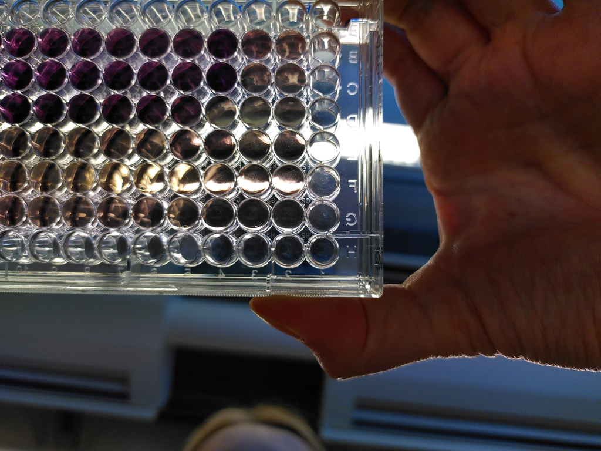

In this picture you can see some of the wells are purple (= very alive/metabolically active) and some are yellow-ish (dead/not metabolically active). In the platereader, this results in a high read-out for purple and low for yellow. (It measures absorbance at 560nm).

Each well is set up and analysed in triplicate. In this particular assay, due to having to dissolve crystals with a multichannel pipette, it is quite likely there will be some wells with very odd, outlier values, which need to be left out of the analysis. So, an important step here is to identify and filter those observations which have a very high SD, before doing the actual analysis.

So, lets get to it!

# Packages

## citation

```r
citation("drc")
```

```
##
##
##   Ritz, C., Baty, F., Streibig, J. C., Gerhard, D. (2015) Dose-Response
##   Analysis Using R PLOS ONE, 10(12), e0146021
##
## A BibTeX entry for LaTeX users is
##
##   @Article{,
##     title = {Dose-Response Analysis Using R},
##     author = {C. Ritz and F. Baty and J. C. Streibig and D. Gerhard},
##     journal = {PLOS ONE},
##     volume = {10},
##     issue = {12},
##     number = {e0146021},
##     year = {2015},
##     url = {http://journals.plos.org/plosone/article?id=10.1371/journal.pone.0146021},
##   }
```

# Data import

Data for this experiment is collected in 96 well plates. In the file plateLayout.xlsx this is stored. Each plate is the same in layout, but the difference betwee different files is the compound, and the timepoint. We will first make a design table with the files to be imported for this analysis.

I’m using regular expressions to extract the information about the compound and timepoint. This is the pattern argument in the str_extract function. Regular expressions allow you to search for literal matches against a pattern (i.e. find “compound” in a string), but what is most useful about them is they allows for partial matching, or searching for information right after a word (which is what I’ve used here). Especially if your names are not all the same length this is very helpful. The first pattern extracts from the file name compound + the character after compound (this is called a wildcard, the full stop .) The second pattern for timepoint extracts t=, followed by two digits (\d) and h. If your filenames are more inconsistently named such as with multiple _, " " or ; , you can also make a regular expression that is more flexible than the two used here (you can also say things like: match “compound[any number of whitespace].”

```r
design_table <- data.frame(fileName = list.files("files/"), filePath = file.path("files", list.files("files/")))

design_table <- design_table %>%
  mutate(compound = str_extract(fileName, pattern = "compound."),
  timepoint = str_extract(fileName, pattern = "t=\\d\\dh"))


knitr::kable(design_table)
```

| fileName | filePath | compound | timepoint |
| --- | --- | --- | --- |
| 2021-08-11 MTT compoundA t=24h.xls | files/2021-08-11 MTT compoundA t=24h.xls | compoundA | t=24h |
| 2021-08-11 MTT compoundB t=24h.xls | files/2021-08-11 MTT compoundB t=24h.xls | compoundB | t=24h |
| 2021-08-12 MTT compoundA t=48h.xls | files/2021-08-12 MTT compoundA t=48h.xls | compoundA | t=48h |
| 2021-08-12 MTT compoundB t=48h.xls | files/2021-08-12 MTT compoundB t=48h.xls | compoundB | t=48h |

## defining an import function

Our import function needs two bits of information to go in: the plate layout (from plateLayout.xlsx, the sheet plateLayout), and the data which we are looking for. This layout corresponds to the data in the data tables, sheet Plate_Page1, rows 7-14, columns A-L. We will use read_excel for this which allows to specify a range to import.

In the end, we want to have a table with as columns cellType, compound, timepoint, concentration, value. I wil first show how to import 1 single file in this way, and then how to extend this to multiple files based on the design table. This helps us to know how to exactly write this data import function.

```r
plate1  <- read_excel(design_table$filePath[1], range = "A7:L14", sheet = "Plate_Page1", col_names = FALSE)
#we will rename them like the plate layout colnames and rownames
colnames(plate1) <- c(1:12)
plate1$rowNames <- LETTERS[1:8]

knitr::kable(plate1)
```

| 1 | 2 | 3 | 4 | 5 | 6 | 7 | 8 | 9 | 10 | 11 | 12 | rowNames |
| --- | --- | --- | --- | --- | --- | --- | --- | --- | --- | --- | --- | --- |
| 0.0389484 | 0.0400670 | 0.0414401 | 0.0396806 | 0.0403752 | 0.0397274 | 0.0395641 | 0.0397487 | 0.0395671 | 0.0389624 | 0.0388963 | 0.0390339 | A |
| 0.0395981 | 0.7862614 | 1.0017501 | 1.2850912 | 1.3626303 | 1.3217314 | 1.1587579 | 1.0539541 | 1.0102847 | 0.9606909 | 0.9207127 | 0.2060996 | B |
| 0.0411829 | 0.7818329 | 1.0242846 | 1.2481911 | 1.3248812 | 1.2987320 | 1.1645791 | 1.0193899 | 0.9502337 | 0.9242263 | 0.8986915 | 0.2301520 | C |
| 0.0404859 | 0.7351868 | 0.8832925 | 1.0806322 | 1.2306889 | 1.3206169 | 1.2073760 | 1.1052980 | 0.9447538 | 1.0030707 | 0.9014871 | 0.2169459 | D |
| 0.0395265 | 0.4483962 | 0.5148205 | 0.7270745 | 0.8472373 | 0.9237797 | 0.9109123 | 0.9696406 | 0.8727316 | 0.9215954 | 0.9554133 | 0.9283273 | E |
| 0.0399096 | 0.4065032 | 0.4987524 | 0.6796154 | 0.8071872 | 0.8502570 | 0.8792286 | 0.8531399 | 0.7840820 | 0.9087422 | 1.0536718 | 0.9790161 | F |
| 0.0405126 | 0.4125284 | 0.4604705 | 0.7668545 | 0.8377905 | 0.8957481 | 0.9875149 | 0.8877884 | 0.8628818 | 0.9236589 | 1.0063365 | 0.8664933 | G |
| 0.0395774 | 0.0396697 | 0.0395732 | 0.0396157 | 0.0391521 | 0.0397535 | 0.0401283 | 0.0389957 | 0.0400323 | 0.0699535 | 0.0658929 | 0.2384576 | H |

So, this was pretty easy to read into R. We now want to melt it to get to a format where each row is only 1 observation. To identify each observation, we want to have the well ID (A1, A2, A3 etc. ) as another column.

```r
plate1_long <- plate1 %>%
  pivot_longer(cols = paste0(c(1:12)))%>%
  mutate(wellID = paste0(rowNames, name)) %>%
  dplyr::select(wellID, value)

knitr::kable(head(plate1_long))
```

| wellID | value |
| --- | --- |
| A1 | 0.0389484 |
| A2 | 0.0400670 |
| A3 | 0.0414401 |
| A4 | 0.0396806 |
| A5 | 0.0403752 |
| A6 | 0.0397274 |

Done! Now we need to involve the plate layout and do the same with the plate layout

```r
plateLayout <- read_excel("plateLayout.xlsx", sheet = "PlateLayout", range = "A1:M9")

plateLayout_long <- plateLayout %>%
  pivot_longer(cols = paste0(c(1:12)))%>%
  mutate(wellID = paste0(rowNames, name)) %>%
  dplyr::select(wellID, value) %>%
  filter(!is.na(value))

knitr::kable(head(plateLayout_long))
```

| wellID | value |
| --- | --- |
| B2 | CellType:Cells1;Concentration_uM:10 |
| B3 | CellType:Cells1;Concentration_uM:3.33333333333333 |
| B4 | CellType:Cells1;Concentration_uM:1.11111111111111 |
| B5 | CellType:Cells1;Concentration_uM:0.37037037037037 |
| B6 | CellType:Cells1;Concentration_uM:0.123456790123457 |
| B7 | CellType:Cells1;Concentration_uM:0.0411522633744856 |

The information in the value column here still needs to be splitted a bit more to separate columns. Here I’m splitting value into CellType and Concentration, removing the column number information, and converting Concentration to a numeric variable.

```r
plateLayout_long <- plateLayout_long %>%
  separate(value, sep = ";", into = c( "cellType", "concentration_uM"))%>%
  mutate(cellType = gsub("CellType:", "", cellType),
         concentration_uM = as.numeric(gsub("Concentration_uM:", "", concentration_uM)))

knitr::kable(head(plateLayout_long))
```

| wellID | cellType | concentration_uM |
| --- | --- | --- |
| B2 | Cells1 | 10.0000000 |
| B3 | Cells1 | 3.3333333 |
| B4 | Cells1 | 1.1111111 |
| B5 | Cells1 | 0.3703704 |
| B6 | Cells1 | 0.1234568 |
| B7 | Cells1 | 0.0411523 |

The last step in our function should be to merge the plateLayout with the plate data. We can do this using wellID, and we only need to keep the wellIds present in the plate layout. We will then use the design table first row to add the sample information from these observations!

```r
plate1_data <- merge(plateLayout_long, plate1_long, by = "wellID", all.x = TRUE)

plate1_data <- cbind(plate1_data, design_table[1,])

knitr::kable(head(plate1_data))
```

| wellID | cellType | concentration_uM | value | fileName | filePath | compound | timepoint |
| --- | --- | --- | --- | --- | --- | --- | --- |
| B10 | Cells1 | 0.0015242 | 0.9606909 | 2021-08-11 MTT compoundA t=24h.xls | files/2021-08-11 MTT compoundA t=24h.xls | compoundA | t=24h |
| B11 | Cells1 | 0.0000000 | 0.9207127 | 2021-08-11 MTT compoundA t=24h.xls | files/2021-08-11 MTT compoundA t=24h.xls | compoundA | t=24h |
| B2 | Cells1 | 10.0000000 | 0.7862614 | 2021-08-11 MTT compoundA t=24h.xls | files/2021-08-11 MTT compoundA t=24h.xls | compoundA | t=24h |
| B3 | Cells1 | 3.3333333 | 1.0017501 | 2021-08-11 MTT compoundA t=24h.xls | files/2021-08-11 MTT compoundA t=24h.xls | compoundA | t=24h |
| B4 | Cells1 | 1.1111111 | 1.2850912 | 2021-08-11 MTT compoundA t=24h.xls | files/2021-08-11 MTT compoundA t=24h.xls | compoundA | t=24h |
| B5 | Cells1 | 0.3703704 | 1.3626303 | 2021-08-11 MTT compoundA t=24h.xls | files/2021-08-11 MTT compoundA t=24h.xls | compoundA | t=24h |

## write function for data import

We now need to combine this information for all the rows in the design_table. For now, we have 1 plate layout for all plates. If you have an experiment where this is not the case, you can add a new column in the design table specifying where each corresponding plate layout is located and read a separate plate layout per file. However, it is fo course always much easier if they’re all the same.

The design table needs to contain a column called filePath which points to the excel file.

I’m using two functions using the guideline that one single function should be to perform 1 task. So 1 function is for importing the data files as single dataframes, and the wrapper function (or the final function), uses this singlePlateImport to import all plates form the design table.

Having this single import as a separate function allows you to customize your script better to new situations, as you will have to make each change only once.

```r
importSinglePlateFile <- function(plateLayout_long, design_table, i){

  # suppressmessages is because ReadXL otherwise has a message for each column that is not named
  plate1  <- suppressMessages(read_excel(design_table$filePath[i], range = "A7:L14", sheet = "Plate_Page1", col_names = FALSE))
  colnames(plate1) <- c(1:12)
  plate1$rowNames <- LETTERS[1:8]

  plate1_long <- plate1 %>%
    pivot_longer(cols = paste0(c(1:12)))%>%
    mutate(wellID = paste0(rowNames, name)) %>%
    dplyr::select(wellID, value)

  plateData <- merge(plateLayout_long, plate1_long, by = "wellID", all.x = TRUE)

  plateData <- cbind(plateData, design_table[i,])

}

# test function
 tempplate <- importSinglePlateFile(plateLayout_long, design_table, 1)

importPlateReaderData <- function(path_to_plateLayout, design_table){

  # import plate layout

  plateLayout <- read_excel(path_to_plateLayout, sheet = "PlateLayout", range = "A1:M9")

  plateLayout_long <- plateLayout %>%
    pivot_longer(cols = paste0(c(1:12)))%>%
    mutate(wellID = paste0(rowNames, name)) %>%
    dplyr::select(wellID, value) %>%
    filter(!is.na(value)) %>%
    separate(value, sep = ";", into = c( "cellType", "concentration_uM"))%>%
    mutate(cellType = gsub("CellType:", "", cellType),
           concentration_uM = as.numeric(gsub("Concentration_uM:", "", concentration_uM)))

  # printing helps to see if what is happening is what you want to happen
  print(head(plateLayout_long))

  # read the first plate

  plateData <- importSinglePlateFile(plateLayout_long = plateLayout_long,
                                     design_table = design_table ,
                                     i = 1)

  print("first import completed!")
  # continue to the other plates

  for(i in 2:nrow(design_table)){

    newPlateData <- importSinglePlateFile(plateLayout_long = plateLayout_long,
                                     design_table = design_table ,
                                     i = i)

    plateData <- rbind(plateData, newPlateData)


    print(paste0(i, " th row completed "))
  }


  return(plateData)
}
```

```r
plateReaderData <- importPlateReaderData(path_to_plateLayout = "plateLayout.xlsx", design_table = design_table)
```

```
## # A tibble: 6 × 3
##   wellID cellType concentration_uM
##   <chr>  <chr>               <dbl>
## 1 B2     Cells1            10
## 2 B3     Cells1             3.33
## 3 B4     Cells1             1.11
## 4 B5     Cells1             0.370
## 5 B6     Cells1             0.123
## 6 B7     Cells1             0.0412
## [1] "first import completed!"
## [1] "2 th row completed "
## [1] "3 th row completed "
## [1] "4 th row completed "
```

So, thats the first step taken: all data imported. This is of course only very few files but you can easily extend this to as many files as you want to import.

```r
plateReaderData$cellType <- factor(plateReaderData$cellType, levels = c("Cells1", "Cells2"))

plateReaderData$compound <- factor(plateReaderData$compound, levels = c("compoundA", "compoundB"))

plateReaderData$timepoint <- factor(plateReaderData$timepoint, levels = c("t=24h", "t=48h"))


plateReaderData <- plateReaderData %>%
  dplyr::select(cellType, timepoint, compound,concentration_uM, value, fileName, filePath) %>%
  group_by(cellType, compound, timepoint, concentration_uM) %>%
  mutate(replicateID = paste0("rep_", 1:n())) %>%
  mutate(median = median(value), sd = sd(value)) %>%
  ungroup() %>%
  mutate(dev_obs  = abs(value - median)>sd)
```

# Filtering outliers

The standard deviation shows for most replicates, this is below 15% of the median. Since this assay sometimes records very high SDs, we will take a closer look at those.

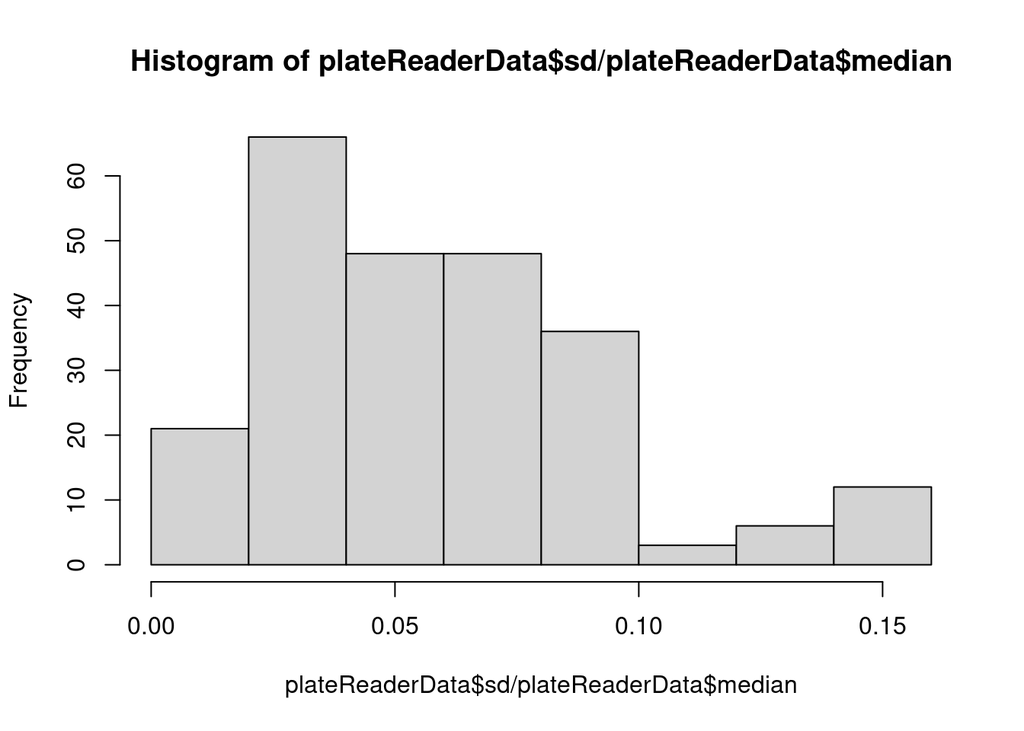

```r
hist(plateReaderData$sd/plateReaderData$median)
```

Within each replicate group, I’ve now calculated the median and sd. Since there are 3 replicates, the median is always the middle observation. This means that if there is an outlier (which we know based on the SD being very large), 1 observation is equal to the median, 1 observation is close, and the other one is very far from the median. This means that if X is an observation within a group, for the measurement that is furthest away from the other two, X-median > SD. When filtering on both having a high SD , and whether this observation is furthest form the mean, you can exclude outlier values.

This is of course depending on the type of assay whether this is suitable.

```r
plateData_high_var <- plateReaderData %>%
  filter( sd/median > 0.15)
```

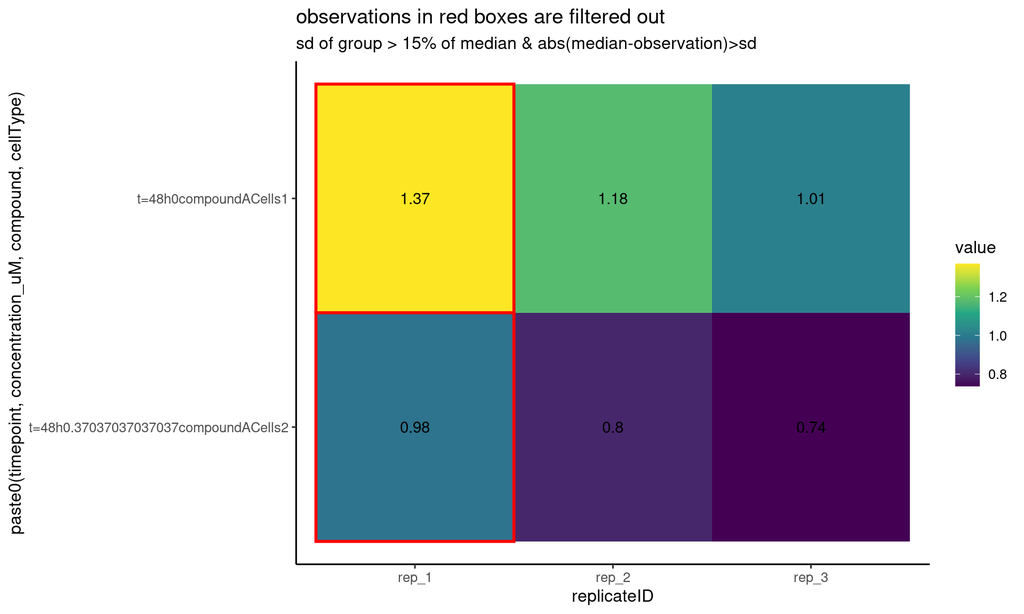

```r
ggplot(data = plateData_high_var,
       aes(x = replicateID, y =paste0(timepoint, concentration_uM,compound,cellType),
           fill = value, label = round(value,2)))+
  geom_tile()+
  scale_fill_viridis_c()+
  geom_tile(data = plateData_high_var%>%filter(dev_obs), color = "red", size = 1)+
  geom_text()+
  theme_classic2()+
  ggtitle("observations in red boxes are filtered out", subtitle = "sd of group > 15% of median & abs(median-observation)>sd")
```

```r
ggsave(filename =  "filtering_heatmap.png")
```

## Exclude outliers based on the criteria above

```r
plateReaderData_filtered <- plateReaderData %>% filter(!(dev_obs & sd/median>0.15))
```

# Heatmaps

For heatmaps, per group, I’m first calculated the mean, and then normalising versus the maximum value per celltype, compound and treatment group. In actual experiments, I also often have a background to subtract but I haven’t got that here.

```r
# these are filtered out

plateReaderData_filtered_summary <- plateReaderData_filtered %>%
  group_by(cellType, compound, timepoint, concentration_uM) %>%
  summarise(mean = mean(value)) %>%
  ungroup() %>%
  group_by(cellType, compound, timepoint) %>%
  mutate(mean_over_max = mean / max(mean)) %>%ungroup()
```

[output not shown]

So, this has summarised our experiment. Let’s quickly look at a heatmap to get a first overview of the treatment!

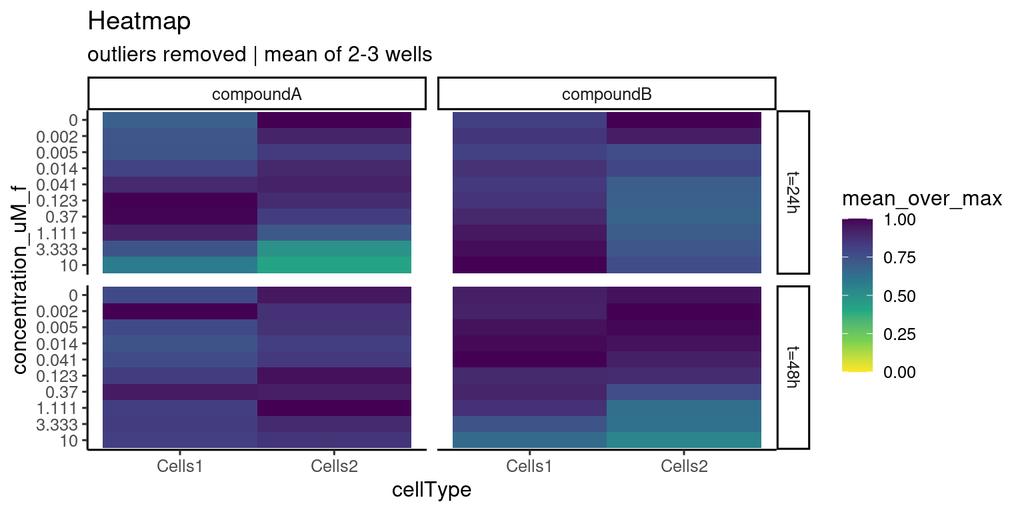

```r
# this converts the concentration to a factor, which makes it easier to invert the axis

plateReaderData_filtered_summary$concentration_uM_f <- factor(round(plateReaderData_filtered_summary$concentration_uM, 3),
                                                              levels = rev(levels(factor(round(plateReaderData_filtered_summary$concentration_uM,3)))))

ggplot(data = plateReaderData_filtered_summary, aes(x = cellType, y = concentration_uM_f, fill = mean_over_max))+
         geom_tile()+
  scale_fill_viridis_c(limits = c(0,1), direction = -1)+
  facet_grid(timepoint~compound)+
  scale_y_discrete()+
  theme_classic2()+
  ggtitle("Heatmap", subtitle = "outliers removed | mean of 2-3 wells")
```

```r
ggsave(filename =  "heatmap.png")
```

From this it seems apparent Cells2 are more sensitive to our treatments already! But what about the IC50?

# Calculate IC50

We’re now going to use the drc (dose-response curve) package.

```
##
## Estimated effective doses
##
##        Estimate Std. Error
## e:1:50  0.57475    0.19041
##
## Estimated effective doses
##
##        Estimate Std. Error
## e:1:50  0.57475    0.19041
##
## Estimated effective doses
##
##        Estimate Std. Error
## e:1:50 0.184167   0.069409
##
## Estimated effective doses
##
##        Estimate Std. Error
## e:1:50 0.184167   0.069409
##
## Estimated effective doses
##
##        Estimate Std. Error
## e:1:50 -0.20848    0.37013
##
## Estimated effective doses
##
##        Estimate Std. Error
## e:1:50 -0.20848    0.37013
##
## Estimated effective doses
##
##        Estimate Std. Error
## e:1:50  -3.7214     2.0903
##
## Estimated effective doses
##
##        Estimate Std. Error
## e:1:50  -3.7214     2.0903
##
## Estimated effective doses
##
##        Estimate Std. Error
## e:1:50  -3.3008     1.6170
##
## Estimated effective doses
##
##        Estimate Std. Error
## e:1:50  -3.3008     1.6170
```

```
##
## Estimated effective doses
##
##        Estimate Std. Error
## e:1:50  0.29427        NaN
```

```
##
## Estimated effective doses
##
##        Estimate Std. Error
## e:1:50  0.29427        NaN
##
## Estimated effective doses
##
##        Estimate Std. Error
## e:1:50  0.52060    0.40569
##
## Estimated effective doses
##
##        Estimate Std. Error
## e:1:50  0.52060    0.40569
##
## Estimated effective doses
##
##        Estimate Std. Error
## e:1:50 -0.45618    0.11817
##
## Estimated effective doses
##
##        Estimate Std. Error
## e:1:50 -0.45618    0.11817
```

```r
knitr::kable(result_IC50)
```

| compound | timepoint | cellType | IC50 | error |
| --- | --- | --- | --- | --- |
| compoundA | t=24h | Cells1 | 0.5747500 | 0.1904097 |
| compoundA | t=24h | Cells2 | 0.1841666 | 0.0694091 |
| compoundB | t=24h | Cells1 | -0.2084753 | 0.3701266 |
| compoundB | t=24h | Cells2 | -3.7213710 | 2.0902806 |
| compoundA | t=48h | Cells1 | -3.3007670 | 1.6169772 |
| compoundA | t=48h | Cells2 | 0.2942741 | NaN |
| compoundB | t=48h | Cells1 | 0.5205979 | 0.4056873 |
| compoundB | t=48h | Cells2 | -0.4561793 | 0.1181714 |

I’m now changing the factors of the IC50 result to match the data in the plateReader results dataframe, because I want to plot them together. I’m also removing the IC50 that have a high error because I don’t want to use those.

```r
result_IC50$compound <- factor(result_IC50$compound, levels = levels(plateReaderData_filtered$compound))

result_IC50$timepoint <- factor(result_IC50$timepoint, levels = levels(plateReaderData_filtered$timepoint))

result_IC50_f <- result_IC50%>%filter(error < 1 & !is.na(error))


result_IC50_f$IC50_power <- 10^result_IC50_f$IC50
```

```r
knitr::kable(result_IC50_f)
```

| compound | timepoint | cellType | IC50 | error | IC50_power |
| --- | --- | --- | --- | --- | --- |
| compoundA | t=24h | Cells1 | 0.5747500 | 0.1904097 | 3.7562112 |
| compoundA | t=24h | Cells2 | 0.1841666 | 0.0694091 | 1.5281520 |
| compoundB | t=24h | Cells1 | -0.2084753 | 0.3701266 | 0.6187636 |
| compoundB | t=48h | Cells1 | 0.5205979 | 0.4056873 | 3.3158730 |
| compoundB | t=48h | Cells2 | -0.4561793 | 0.1181714 | 0.3498007 |

That’s it!

Let’s get to the final plot. I’ve made two versions: one with geom_point() only, and one with stat_summary which can omit the actual datapoints.

# IC50 Dose-response plot

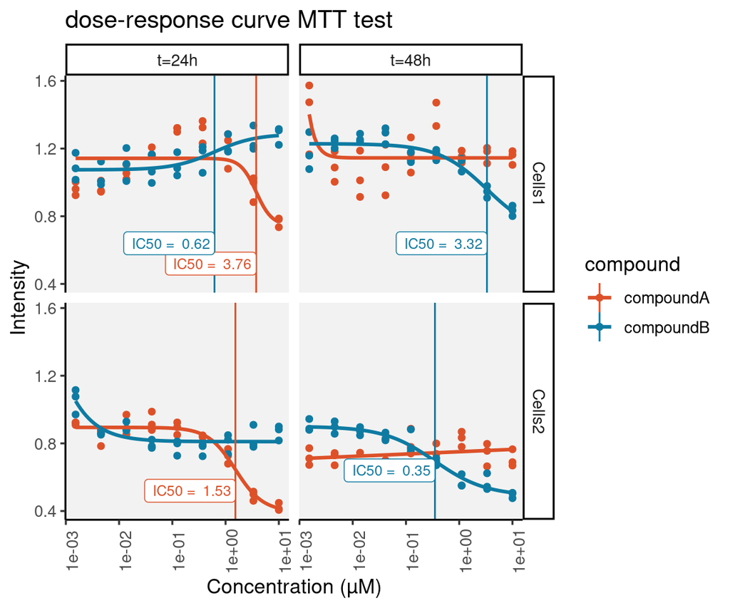

```r
ggplot(data = plateReaderData_filtered%>%filter(concentration_uM>0), aes(x = concentration_uM, y = value, color = compound))+

  # data
  geom_point()+
  geom_smooth(method=drm, method.args = list(fct = L.4()),se=FALSE)+

  # scales and wrap
  scale_x_log10()+
  facet_grid( cellType ~ timepoint)+
  xlab("Concentration (µM)")+
  ylab("Intensity")+

  # text with ic50 value

  geom_vline(data = result_IC50_f, aes(xintercept = IC50_power, color = compound))+
  geom_label(data = result_IC50_f, aes(x = IC50_power, y = 0.4+as.numeric(compound)*0.12, label = paste("IC50 = ", round(IC50_power,2)),
                                      color = compound), hjust = 1, size = 3, show.legend = FALSE)+


  # theme
  theme_classic2()+

  theme(panel.background = element_rect(fill = "grey95"))+
  scale_color_manual(values = met.brewer("Egypt", n = 2) )+
  theme(axis.text.x = element_text(angle = 90))+
  ggtitle("dose-response curve MTT test")
```

```r
ggsave( "dose_response_mtt.png")
```

## only mean and SD

based on this question on [stackoverflow](https://stackoverflow.com/questions/21239418/use-stat-summary-in-ggplot2-to-calculate-the-mean-and-sd-then-connect-mean-poin)

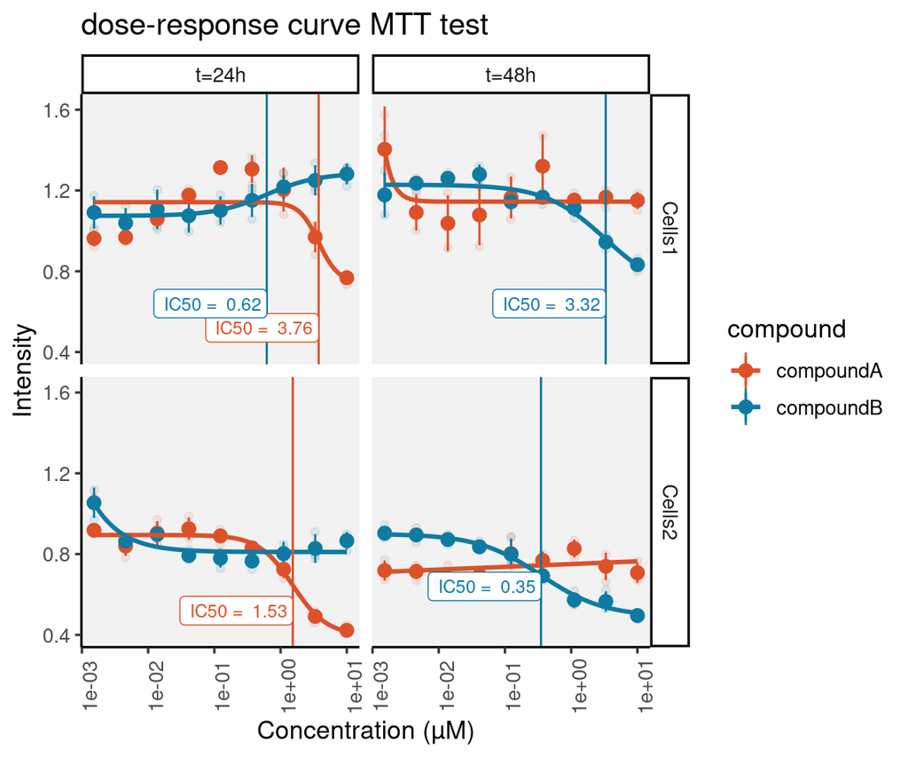

```r
ggplot(data = plateReaderData_filtered%>%filter(concentration_uM>0), aes(x = concentration_uM, y = value, color = compound))+

  # data
  geom_point(alpha = 0.1)+
  stat_summary(fun.y = mean,
               fun.min = function(x) mean(x) - sd(x),
               fun.max = function(x) mean(x) + sd(x))+
  geom_smooth(method=drm, method.args = list(fct = L.4()),se=FALSE)+

  # scales and wrap
  scale_x_log10()+
  facet_grid( cellType ~ timepoint)+
  xlab("Concentration (µM)")+
  ylab("Intensity")+

  # text with ic50 value

  geom_vline(data = result_IC50_f, aes(xintercept = IC50_power, color = compound))+
  geom_label(data = result_IC50_f, aes(x = IC50_power, y = 0.4+as.numeric(compound)*0.12, label = paste("IC50 = ", round(IC50_power,2)),
                                      color = compound), hjust = 1, size = 3, show.legend = FALSE)+


  # theme
  theme_classic2()+

  theme(panel.background = element_rect(fill = "grey95"))+
  scale_color_manual(values = met.brewer("Egypt", n = 2) )+
  theme(axis.text.x = element_text(angle = 90))+
  ggtitle("dose-response curve MTT test")
```

```r
ggsave( "dose_response_mtt_no_ind_points.png")
```